## Problem 1 (3 + 3 + 4 + 2)

### (a)

(3 points) Consider a binary classication problem with $Y\in\{-1,+1\}$ and two real-valued features, $X_1,X_2\in \mathbb{R}$. Suppose that we have learned a (Gaussian) naive Bayes classi er and obtained parameter estimates $\hat{\mu}_{-,j}= 0, \hat{\sigma}^{2}_{-,j}=1$ and $\hat{\mu}_{+,j}= 0, \hat{\sigma}^{2}_{-,j}=16$ for $j\in\{1,2\}$. Further, we use a uniform class prior $\hat{p}(y)=1/2$ for $y\in\{-1,+1\}$. Use the Bayes formula to compute the posterior probability
$$P(Y = +1 | X_1 = 1,X_2 = 2)$$

#### Answer:

Bayes formula:
$$P(A|B) = \frac{P(A)P(B|A)}{P(B)}$$
$$P(Y = +1 | X_1 ,X_2) \\ \\
= \frac{P(Y = +1 )P(X_1,X_2|Y = +1 )}{P(X_1,X_2)} \\
= \frac{P(Y = +1 )P(X_1|Y = +1 )P(X_2|Y = +1 )}{P(X_1,X_2)} (Naive \ Bayes)\\$$

Further calculation on paper lead to

$$P(Y = +1 | X_1 ,X_2) = \frac{e^{\frac{-(x_1 + x_2)}{32}}}{e^{-\frac{-(x_1 + x_2)}{32}}+e^{\frac{-(x_1 + x_2)}{2}}}\\ \\$$
Define this as R function probYplus1(x1,x2):

```r
probYplus1 <- function(x1,x2)
{
  px1 = exp(-(x1+x2)/32)
  px2 = exp(-(x1+x2)/2)
  return(px1/(px1+px2))
}
probYminus1 <- function(x1,x2)
{
  px1 = exp(-(x1+x2)/32)
  px2 = exp(-(x1+x2)/2)
  return(px2/(px1+px2))
}
```

```r
probYplus1(1,2)
```

```
## [1] 0.8031738
```

```r
probYminus1(1,2)
```

```
## [1] 0.1968262
```

$$P(Y = +1 | X_1=1 ,X_2=2) = \frac{e^{\frac{-(1 + 2)}{32}}}{e^{-\frac{-(1 + 2)}{32}}+e^{\frac{-(1 + 2)}{2}}} = 0.803\\$$
## (b) (3 points) Visualize the class posterior $P(Y = +1 | x)$, where $x = (x1, x2) contains the observed feature values on a suitable grid of points. Hint: This is quite similar to Exercise 2.1.

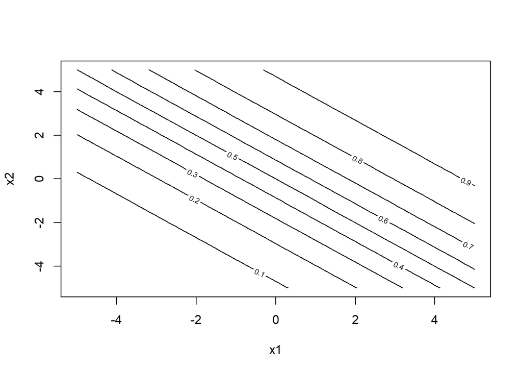

```r
#create grid
xgrid <- .25*(-20:20)
ygrid <- .25*(-20:20)
grid <- expand.grid(xgrid, ygrid)
py = probYplus1(grid[,1],grid[,2])
pyDraw <- matrix(py, nrow=41, ncol=41)

contour(xgrid, ygrid, pyDraw, xlab="x1", ylab="x2")
```

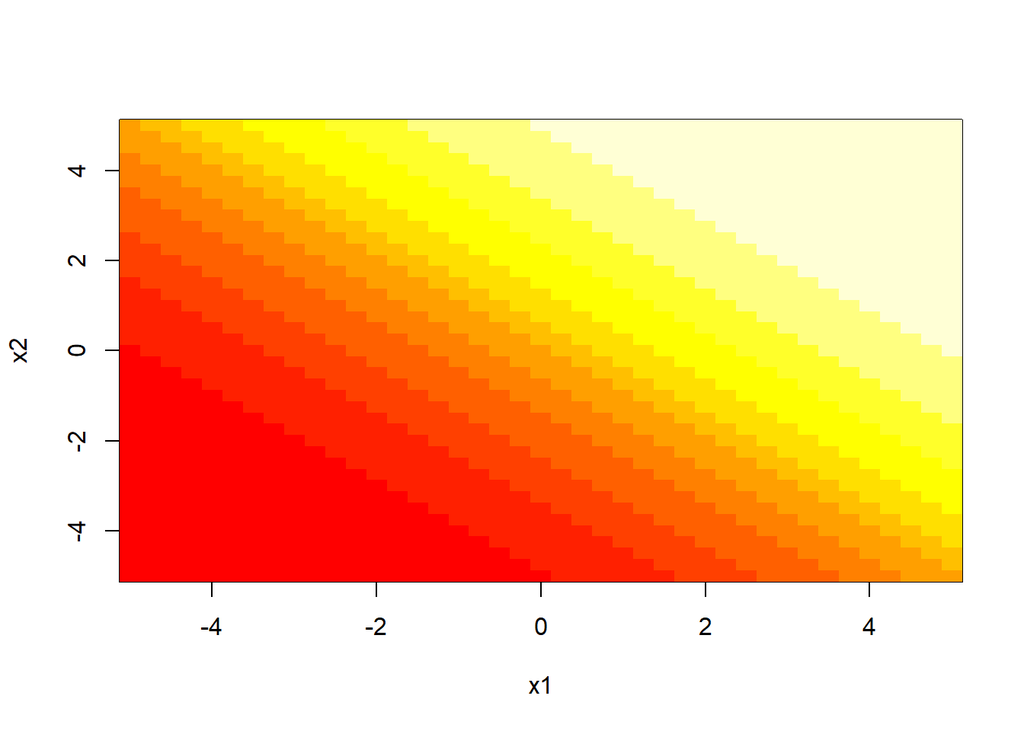

```r
image(xgrid, ygrid, pyDraw, xlab="x1", ylab="x2")
```

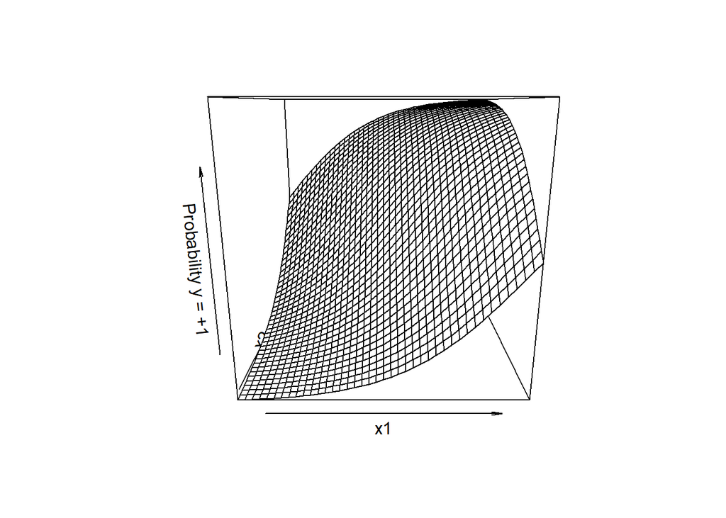

```r
persp(xgrid, ygrid, pyDraw, zlab="Probability y = +1", xlab="x1", ylab="x2")
```

```r
py[1:5]
```

```
## [1] 0.009125637 0.010248602 0.011508149 0.012920473 0.014503580
```

[output not shown]

```
## [1] 0.008508277
```